# Homework 2

STAT 363

Anonymous

Due: Thursday May 12th 2022 by 2:00 pm

# General Information

## Logistics

- Make a copy of this template to write out your solution, DO NOT rename it. Then knit it as `HW02.Rmd`.
- Inside this .Rmd file do not include any personal identifier (such as your name, Odin ID, etc.).
- Knit your `Rmd` file as `html` and upload both the `Rmd` and `html` files with your solution to D2L in `Assignments > Homework 2` before Thursday May 12th 2022 by 2:00 pm.

## Objectives for this week’s homework

1. Practice making figures in both base R and ggplot2
2. Generate hypotheses and explore them graphically

# Your Task

Write down ONLY ONE question or hypothesis you are interested in exploring from the *world powerplant dataset* found in the [information is beautiful](https://informationisbeautiful.net/visualizations/mega-what-the-worlds-biggest-and-most-notable-power-plants/) website, which includes some nice visualizations. The original data can be found [here](http://datasets.wri.org/dataset/globalpowerplantdatabase) along with a brief description. You might want to work with just a subset of the data (e.g. one particular country), or you may choose to transform or summarize your data in the way that best allows you to explore your question.

Note that inside of the `globalpowerplant` folder in Canvas the homework folder there are additional documents with information that may prove useful, in particular be sure to look at the `README.txt` file, which includes the metadata (a description of the variables) in the **Fields** section.

**The idea is for you to investigate your question/hypothesis graphically. To do so, generate the figures you consider necessary – at least two and at most 4, and note that more figures is not necessarily better, fewer but very well thought-out and informative figures can usually do the trick. At least one of your figures should be built using `base R` and at least one using `ggplot`.**

All titles, axes, and legends should be labeled clearly (no raw variable names). You must have at least one graph with `facet_wrap` or `facet_grid`. You must include at least one manually specified legend. You can use other `geoms` like histograms, bar charts, add vertical or horizontal lines, etc. [You may find this data visualization cheat sheet helpful](https://www.rstudio.com/wp-content/uploads/2016/11/ggplot2-cheatsheet-2.1.pdf).

Your document should be aesthetically pleasing, with some organization. You must write up your observations in words as well as showing the graphs. Use chunk options `echo` and `results` to limit the code/output you show in the `.html`.

Below I load in the data, but be careful, there are many rows that you may need to filter out to remove `NA`s in some of your variables of interest.

Have fun and Good Luck!!

### Helper Functions

```r
PlotPower <- function(funcDF, xargString, yargString, targetString, sizeString, title) {

  # Gets the number of unique values from the target column
  targets=unique(power[,targetString])
  n_targets = length(targets)

  #col=rgb(red=0.2, green=0.2, blue=1.0, alpha=0.2)

  # Sets the color palette
  col.vec <- rep(
    hsv(0.5, 0.75, seq(.45,.90,length.out = n_targets), alpha=0.3),
    targets=unique(power[,targetString])
  )

  # Sets the size of each dot
  obj.size <- seq(0.4,1.5,length.out = length(power[,sizeString]))

  # Plots the graph
  plot(
    x = power[,xargString],
    y = power[,yargString],
    xlab = xargString,
    ylab = yargString,
    main = title,
    type = "p",
    lty = 1, lwd = 1,
    pch = 16,
    cex = obj.size, cex.axis = 1, cex.lab = 1,
    col = col.vec
  )

  par(mar=c(2, 4, 4, 8), xpd=TRUE)

  legend(
    "bottomright",
    inset=c(0, 0),
    bty = "n",
    pch=c(16,16,16),
    col=col.vec,
    legend=targets
  )
}

# This function creates a new column called 'Renewable' and labels each energy
# type as either renewable or non-renewable according to EIA.gov"
GetRenewable <- function(funcDF) {
  funcDF <- funcDF %>%
  mutate(renewable = case_when(
    (primary_fuel == "Hydro") ~ "Renewable",
    (primary_fuel == "Solar") ~ "Renewable",
    (primary_fuel == "Geothermal") ~ "Renewable",
    (primary_fuel == "Biomass") ~ "Renewable",
    (primary_fuel == "Wind") ~ "Renewable",
    (primary_fuel == "Coal") ~ "Non-Renewable",
    (primary_fuel == "Cogeneration") ~"Non-Renewable",
    (primary_fuel == "Gas")~"Non-Renewable",
    (primary_fuel == "Nuclear") ~"Non-Renewable",
    (primary_fuel == "Other") ~ "Non-Renewable",
    (primary_fuel == "Petcoke") ~"Non-Renewable",
    (primary_fuel == "Storage")~"Non-Renewable",
    (primary_fuel == "Waste") ~"Non-Renewable",
    (primary_fuel == "Wave and Tidal") ~"Non-Renewable",
    (primary_fuel == "Oil") ~"Non-Renewable"
  ))

  return(data.frame(funcDF))
}

# This function gets the age of the power plants and puts that into a new column
GetFacilityAge <- function(funcDF) {

  currentYear = as.integer(format(Sys.Date(), "%Y"))

  return(data.frame(transform(funcDF, facilityAge = (currentYear - floor(commissioning_year)))))
}

# This function creates a new
GetHighIncome <- function(funcDF) {
  funcDF <- funcDF %>%
  mutate(income = case_when(
    (gdpPerCapita >= 12696) ~ "HighIncome",
    (gdpPerCapita < 12696) ~ "LowIncome",
  ))

  return(data.frame(funcDF))
}
```

```r
power <- read.csv('globalpowerplant/global_power_plant_database.csv',
                  na.strings = c(NA,"","NA"),
                  header=T)
```

Recall that you can test (and filter out) for `NAs` using the function `is.na`, which is vectorized! If, for example you want to remove rows with NA’s in the variable `year_of_capacity_data`, you can use the following line of code (look at week 2’s class notes for more information about this).

```r
power <- power %>% dplyr::filter(!is.na(year_of_capacity_data) )
```

# Your question or hypothesis

Use this section to type in the question you want to explore.

## My Hypothesis

**Higher income countries are more likely to utilize renewable energy sources since they have more income and financial resources to use in order to invest in more renewable resources and renewable resource research. So we should see higher income countries utilize more renewable resources.**

### Data Exploration

The pair plot was used to find any correlations from the data.

```r
keeps <- c("country","country_long", "capacity_mw", "latitude", "longitude", "primary_fuel", "facilityAge", "estimated_generation_gwh", "renewable", "year_of_capacity_data")

power <- GetRenewable(power)
power <- GetFacilityAge(power)

power <- power[keeps]

head(power, 10)
```

```
##    country country_long capacity_mw latitude longitude primary_fuel facilityAge
## 1      AFG  Afghanistan       33.00  32.3220   65.1190        Hydro          NA
## 2      AFG  Afghanistan       66.00  34.5560   69.4787        Hydro          NA
## 3      AFG  Afghanistan      100.00  34.6410   69.7170        Hydro          NA
## 4      AFG  Afghanistan       11.55  34.4847   70.3633        Hydro          NA
## 5      AFG  Afghanistan       42.00  34.5638   69.1134          Gas          NA
## 6      AFG  Afghanistan        6.00  35.9416   68.7100        Hydro          NA
## 7      AFG  Afghanistan       22.00  34.5865   69.7757        Hydro          NA
## 8      ARG    Argentina      479.20 -38.9368  -68.3556        Other          25
## 9      ARG    Argentina      192.00 -38.9368  -68.3556          Gas          29
## 10     ARG    Argentina      130.00 -34.5792  -68.9892        Hydro          40
##    estimated_generation_gwh     renewable year_of_capacity_data
## 1                        NA     Renewable                  2017
## 2                        NA     Renewable                  2017
## 3                        NA     Renewable                  2017
## 4                        NA     Renewable                  2017
## 5                        NA Non-Renewable                  2017
## 6                        NA     Renewable                  2017
## 7                        NA     Renewable                  2017
## 8                    0.0000 Non-Renewable                  2015
## 9                  991.9287 Non-Renewable                  2015
## 10                 537.5396     Renewable                  2015
```

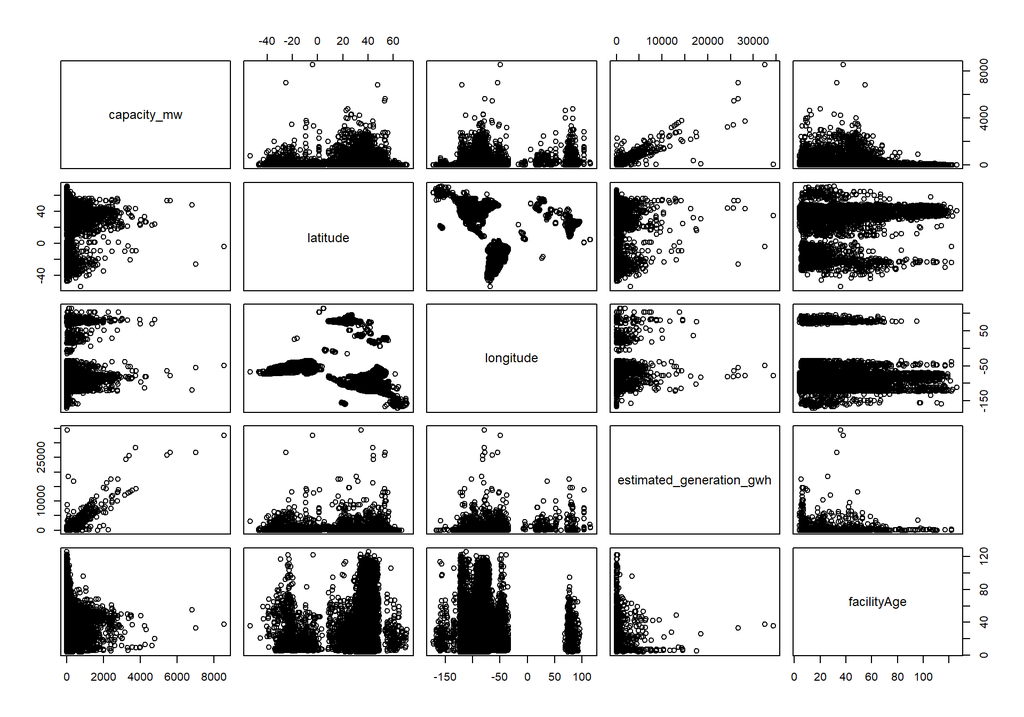

```r
plot.df <- power[, c("capacity_mw", "latitude", "longitude", "estimated_generation_gwh", "facilityAge")]
pairs(plot.df)
```

# Your base R plot(s)

Use this section to include your base R plot or plots

### Conclusion - More Power Being Used by Higher Income Countries

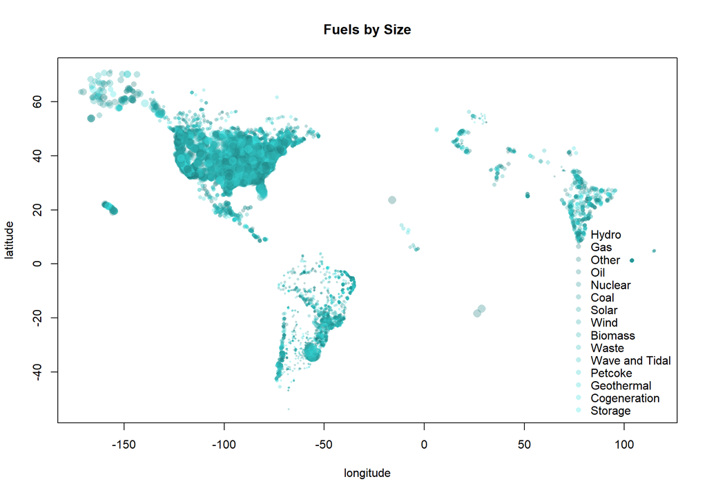

```r
PlotPower(power, "longitude", "latitude", "primary_fuel", "capacity_mw", "Fuels by Size")
```

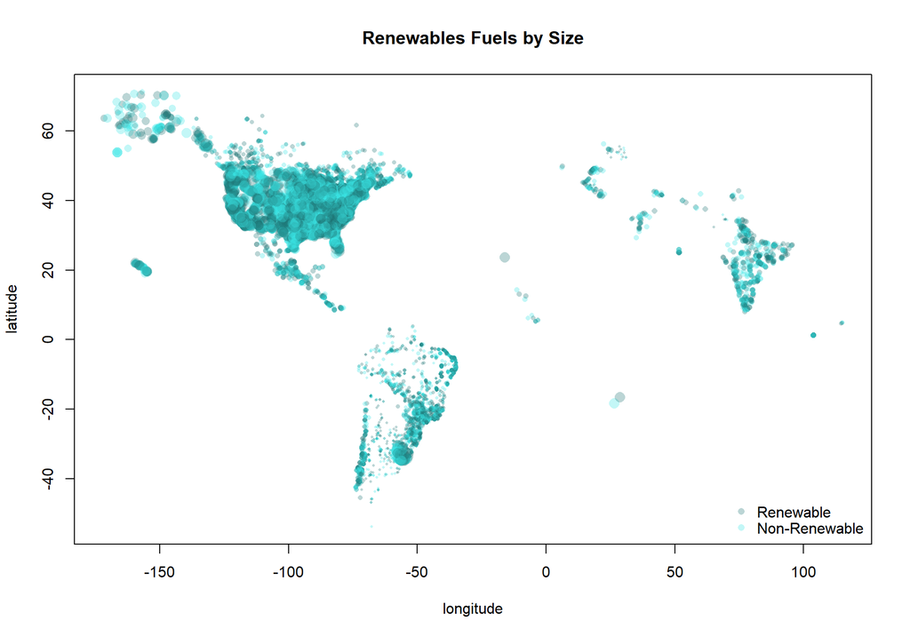

```r
PlotPower(power, "longitude", "latitude", "renewable", "capacity_mw", "Renewables Fuels by Size")
```

### Getting More Information About the Countries

I used a library `wbstats` to get more information about these countries. I specifically wanted their population and gdp per country in order to classify them as high or low income.

```r
library(wbstats)
my_indicators = c("pop" = "SP.POP.TOTL",
                  "gdp" = "NY.GDP.MKTP.CD")
pop_data <- wb_data(
  my_indicators,
  start_date = min(power$year_of_capacity_data),
  end_date = max(power$year_of_capacity_data)
)
keeps <- c("iso3c", "date", "gdp", "pop")

pop_data <- pop_data[keeps]

pop_data <- pop_data %>% rename(
   "country" = "iso3c",
   "year_of_capacity_data" = "date"
)

head(pop_data,10)
```

```
## # A tibble: 10 x 4
##    country year_of_capacity_data         gdp    pop
##    <chr>                   <dbl>       <dbl>  <dbl>
##  1 ABW                      2000 1873452514.  90866
##  2 ABW                      2001 1920111732.  92892
##  3 ABW                      2002 1941340782.  94992
##  4 ABW                      2003 2021229050.  97016
##  5 ABW                      2004 2228491620.  98744
##  6 ABW                      2005 2330726257. 100028
##  7 ABW                      2006 2424581006. 100830
##  8 ABW                      2007 2615083799. 101226
##  9 ABW                      2008 2745251397. 101362
## 10 ABW                      2009 2498882682. 101452
```

### Merge Datasets

```r
power <- merge(power,pop_data,by=c("country","year_of_capacity_data"))
#power <- power[!is.na(power$facilityAge),]
power <- data.frame(transform(power, gdpPerCapita = (gdp / pop)))
head(power, 10)
```

```
##    country year_of_capacity_data country_long capacity_mw latitude longitude
## 1      AFG                  2017  Afghanistan       11.55  34.4847   70.3633
## 2      AFG                  2017  Afghanistan       42.00  34.5638   69.1134
## 3      AFG                  2017  Afghanistan        6.00  35.9416   68.7100
## 4      AFG                  2017  Afghanistan      100.00  34.6410   69.7170
## 5      AFG                  2017  Afghanistan       33.00  32.3220   65.1190
## 6      AFG                  2017  Afghanistan       66.00  34.5560   69.4787
## 7      AFG                  2017  Afghanistan       22.00  34.5865   69.7757
## 8      ARG                  2015    Argentina      130.00 -34.5792  -68.9892
## 9      ARG                  2015    Argentina      479.20 -38.9368  -68.3556
## 10     ARG                  2015    Argentina      192.00 -38.9368  -68.3556
##    primary_fuel facilityAge estimated_generation_gwh     renewable          gdp
## 1         Hydro          NA                       NA     Renewable  18753469630
## 2           Gas          NA                       NA Non-Renewable  18753469630
## 3         Hydro          NA                       NA     Renewable  18753469630
```

[output cut: 18 more lines]

### Defining High Income Countries

A high-income economy is defined by the World Bank as a nation with a gross national income per capita of US$12,696 or more in 2020.

```r
power <- GetHighIncome(power)
head(power, 10)
```

```
##    country year_of_capacity_data country_long capacity_mw latitude longitude
## 1      AFG                  2017  Afghanistan       11.55  34.4847   70.3633
## 2      AFG                  2017  Afghanistan       42.00  34.5638   69.1134
## 3      AFG                  2017  Afghanistan        6.00  35.9416   68.7100
## 4      AFG                  2017  Afghanistan      100.00  34.6410   69.7170
## 5      AFG                  2017  Afghanistan       33.00  32.3220   65.1190
## 6      AFG                  2017  Afghanistan       66.00  34.5560   69.4787
## 7      AFG                  2017  Afghanistan       22.00  34.5865   69.7757
## 8      ARG                  2015    Argentina      130.00 -34.5792  -68.9892
## 9      ARG                  2015    Argentina      479.20 -38.9368  -68.3556
## 10     ARG                  2015    Argentina      192.00 -38.9368  -68.3556
##    primary_fuel facilityAge estimated_generation_gwh     renewable          gdp
## 1         Hydro          NA                       NA     Renewable  18753469630
## 2           Gas          NA                       NA Non-Renewable  18753469630
## 3         Hydro          NA                       NA     Renewable  18753469630
```

[output cut: 18 more lines]

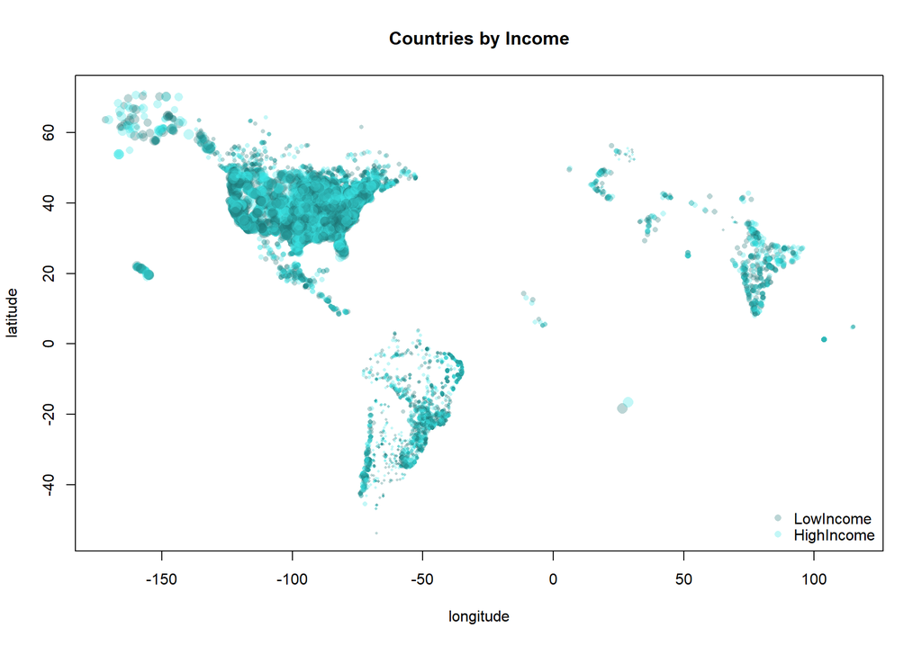

```r
PlotPower(power, "longitude", "latitude", "income", "gdp", "Countries by Income")
```

**Below we can see that both countries are using mostly renewable resources, but the sheer amount of power plants from high income countries out weighs those from lower income countries by a large margin.**

### Plotting Renewables For Low Income Countries

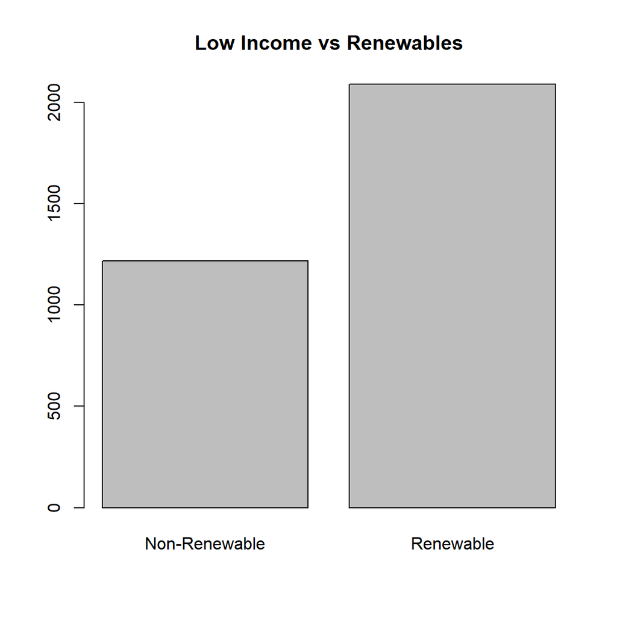

```r
lowIncomePower <- power[(power$income=="LowIncome"),]

barplot(table(lowIncomePower$renewable), main="Low Income vs Renewables")
```

### Plotting Renewables For High Income Countries

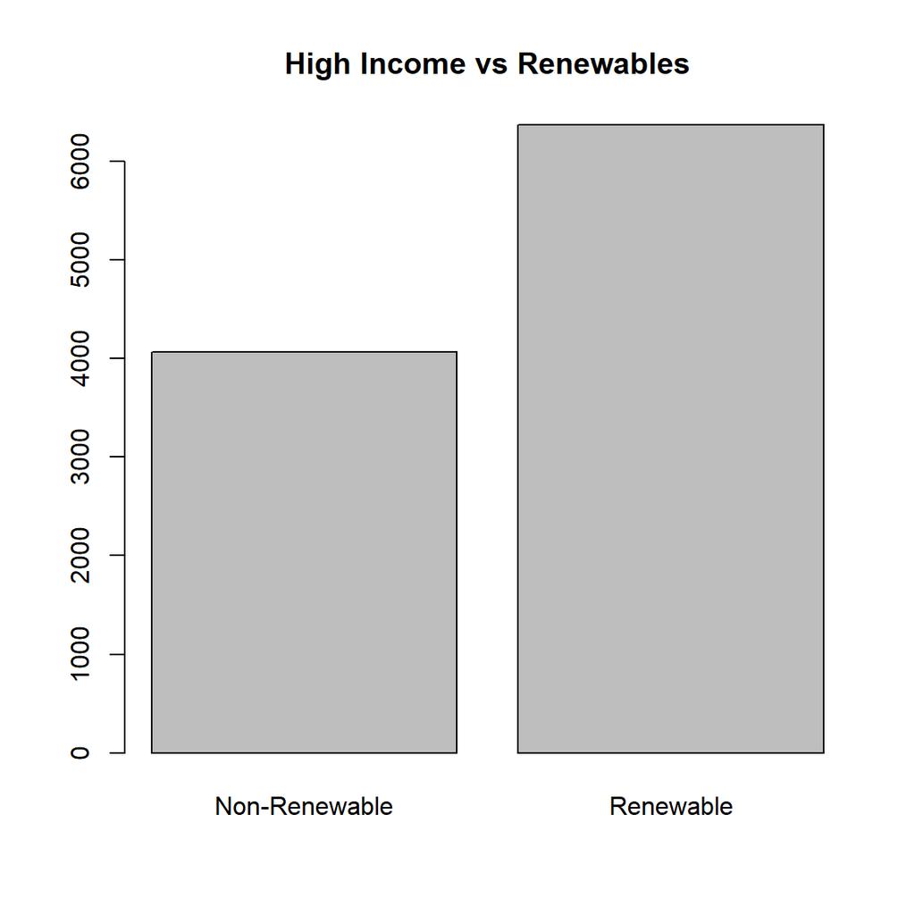

```r
highIncomePower <- power[(power$income=="HighIncome"),]

barplot(table(highIncomePower$renewable), main="High Income vs Renewables")
```

# Your `ggplot` plot(s)

Use this section to include your `ggplot` plot or plots

### Conclusion - Renewable vs Non-Renewable Percentages

**In the ratio plots we can see that there is overall more blue bars (renewable energy sources) being used by lower income countries, and more red bars (non-renewable energy sources) being used by higher income countries. This disproves my initial hypothesis.**

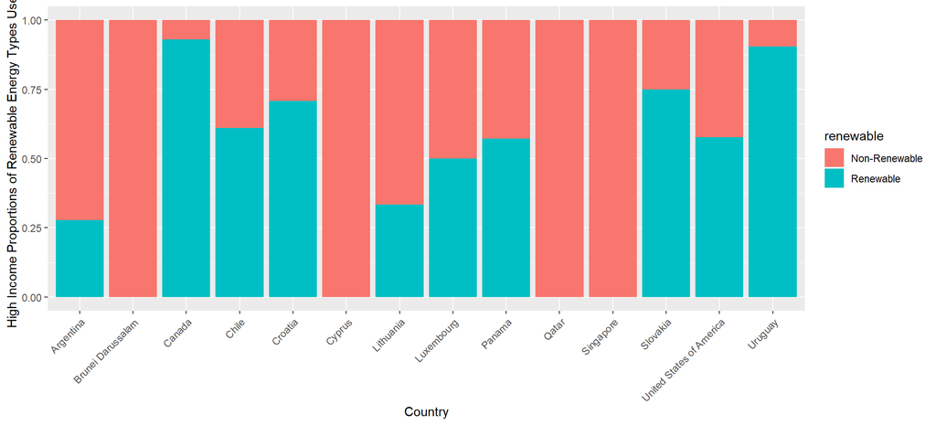

```r
# Proportion of types of fuels used in the country
ggplot(data = highIncomePower, aes(x = country_long, fill = renewable)) +
  geom_bar(position = "fill") +
  ylab("High Income Proportions of Renewable Energy Types Used") +
  xlab("Country") +
  theme(axis.text.x=element_text(angle = 45, hjust = 1))
```

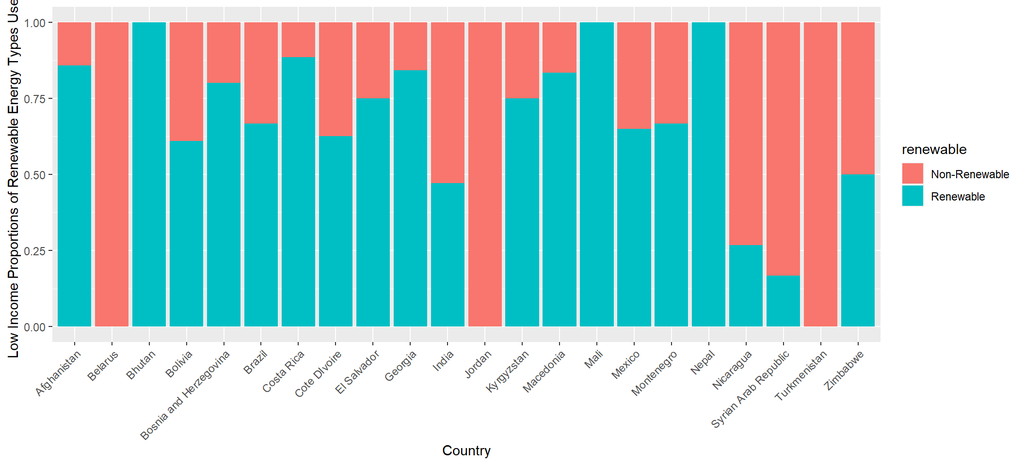

```r
# Proportion of types of fuels used in the country with filtering of useless data
ggplot(data = lowIncomePower, aes(x = country_long, fill = renewable)) +
  geom_bar(position = "fill") +
  ylab("Low Income Proportions of Renewable Energy Types Used") +
  xlab("Country") +
  theme(axis.text.x=element_text(angle = 45, hjust = 1))
```

### Conclusion - Age of Facility

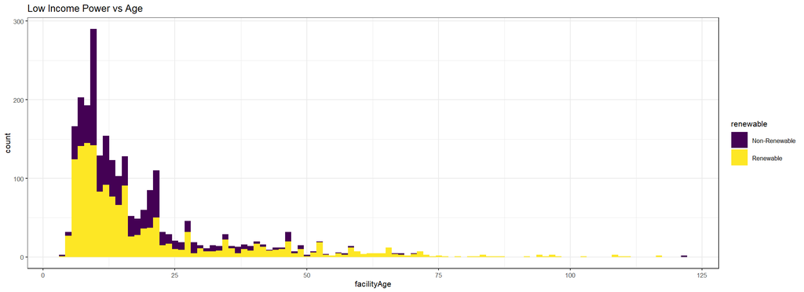

```r
ggplot(
  data=lowIncomePower,
  aes(x=facilityAge, fill=renewable)
) +geom_histogram(bins=100) +theme_bw(base_size=8) +scale_fill_viridis_d() +ggtitle("Low Income Power vs Age")
```

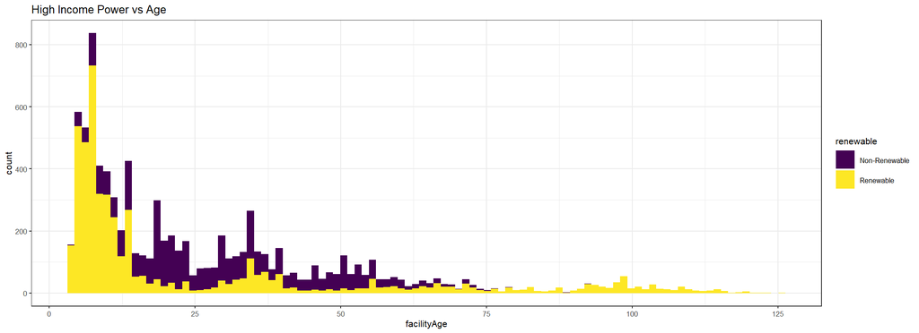

```r
ggplot(
  data=highIncomePower,
  aes(x=facilityAge, fill=renewable)
) +geom_histogram(bins=100) +theme_bw(base_size=8) +scale_fill_viridis_d() +ggtitle("High Income Power vs Age")
```